# ANALYSE DE MÉDIATION CAUSALE POUR DES MÉDIATEURS NON CAUSALEMENT LIÉS

Komi Ayi

Dans le cadre de l’analyse de médiation, un chercheur peut, en toute connaissance de cause, choisir de se concentrer sur un médiateur d’intérêt particulier parmi plusieurs médiateurs présents entre une exposition et une réponse. Cette approche, qui revient à mener une analyse de médiation simple dans un contexte de médiation multiple, vise à estimer l’effet indirect de l’exposition à travers le médiateur cible, ainsi que l’effet direct complémentaire, représentant l’ensemble des autres voies d’influence, y compris celles passant par les autres médiateurs.

Ce chapitre propose une méthodologie pour effectuer une analyse de médiation simple pour un médiateur particulier, en tenant compte de la présence d’un second médiateur présumé non lié causalement au premier. Dans ce contexte, nous supposons donc que ces deux médiateurs sont mesurés.

# Mise en contexte

Considérons le vecteur $\boldsymbol{X}$, qui représente les variables de préexposition, $T$ une variable binaire dite d’exposition, où $T = 1$ indique une exposition et $T = 0$ une absence d’exposition, ainsi que les médiateurs $M_1, M_2$ impliqués dans le mécanisme causal. La variable $U$ représente une cause commune non mesurée des médiateurs, et $Y$ la réponse. La structure causale entre ces éléments est représentée dans le diagramme causal de la Figure Figure 1.

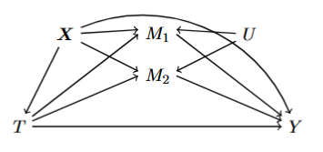

Figure 1: DAG d’analyse de médiation avec deux médiateurs disposant d’une cause commune.

Soit $M_1$ le médiateur auquel on s’intéresse. Nous notons par $\boldsymbol{M}$ le vecteur des deux médiateurs observés. Dans le diagramme causal de la Figure Figure 1, $M_1$ est influencé par $\boldsymbol{X}$, $T$ et la cause commune non mesurée $U$. Cette dernière affecte simultanément $M_1$ et le médiateur $M_2$, ce qui crée une dépendance entre $M_1$ et $M_2$. S’intéresser à un médiateur en particulier conduit à une analyse restreinte, où nous nous concentrons sur le médiateur $M_1$, comme illustré dans le diagramme de la Figure Figure 2, représentant les relations causales directes et indirectes entre $T$, $M_1$ et $Y$. Les chemins $T \to Y$ et $T \to M_2 \to Y$ sont les chemins contribuant à l’effet direct de $T$ sur $Y$ en considérant $M_1$ comme médiateur ciblé, tandis que $T \to M_1 \to Y$ est le chemin indirect via $M_1$. Outre le lien direct de $M_1$ sur $Y$, un chemin non causal existe entre $M_1$ et $Y$, qui passe par $U$, soit $M_1 \leftarrow U \to M_2 \to Y$. Ce chemin représente un chemin de confusion entre $M_1$ et $Y$ par la présence de la cause commune $U$ non mesurée, posant ainsi problème pour l’utilisation de l’approche de médiation simple standard.

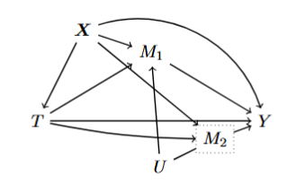

Figure 2: DAG d’analyse simple de $M_1$.

Notre objectif est donc d’identifier et d’estimer les effets naturels simples, direct et indirect de $M_1$, en contournant la difficulté liée à la présence de la variable non mesurée $U$.

Dans la littérature, une solution classique pour mitiger le biais de confusion dans une analyse est d’ajuster ou stratifier sur les confondants. Cependant, comme $U$ n’est pas mesurée, nous ne pouvons pas adopter cette stratégie. L’ajustement sur $M_2$ pourrait effectivement éliminer la confusion entre le médiateur d’intérêt et la réponse qui découle de l’ouverture du chemin $M_1 \leftarrow U \to M_2 \to Y$. Cependant, cette stratégie mène à un autre problème. On bloque le chemin causal $T\to M_2\to Y$, ce qui engendre un biais dans l’estimation de l’effet direct de $T$ sur $Y$ avec $M_1$ comme médiateur d’intérêt. Cela crée un dilemme, car il faut à la fois ajuster et ne pas ajuster pour $M_2$.

Pour résoudre ce dilemme, notre approche dans un premier temps consiste à inclure le médiateur $M_2$ dans l’analyse en adaptant l’hypothèse de composition de Halpern and Pearl (2005) afin de tenir compte de cette structure causale complexe.

## Incorporation du médiateur $M_2$ dans l’analyse de médiation simple

### Définition des effets direct et indirect dans l’analyse de médiation simple

Dans cette section, nous incorporons le médiateur $M_2$ dans l’analyse de médiation simple afin d’évaluer les effets direct et indirect de $M_1$ en tenant compte de la dépendance entre les deux médiateurs. Soit $\boldsymbol{M}(t)$ le vecteur des valeurs potentielles des médiateurs lorsque l’exposition est fixée à $t$. De même, $Y(t,\boldsymbol{M}(t'))$ désigne la valeur potentielle de la réponse lorsque l’exposition est fixée à $t$ et que les médiateurs prennent leurs valeurs potentielles sous une exposition $t'$. Enfin, $Y(t,M_1(t'),M_2(t''))$ représente la valeur potentielle de la réponse lorsque $M_1$ et $M_2$ sont fixés respectivement à leurs valeurs potentielles sous les expositions $t'$ et $t''$.

L’hypothèse de composition s’exprime ainsi :
$$\textbf{(H$_0$)} \quad
Y(t,M_1(t'))=Y(t,M_1(t'),\boldsymbol{M}_2(t)),\;\forall\,t,t'.$$
Cette hypothèse énonce que la valeur potentielle de $Y$ lorsque $T$ est fixé à $t$ et $M_1$ à sa valeur potentielle sous une autre exposition $t'$ est égale à la valeur potentielle de $Y$ lorsque $T$ est fixé à $t$, $M_1$ à sa valeur sous $t'$, et le vecteur $M_2$ à sa valeur potentielle sous $t$. En d’autres termes, l’intervention sur $M_2$ n’a aucun effet supplémentaire sur la réponse potentielle.

Sous cette hypothèse, les effets direct et indirect de $M_1$ sont définis comme suit :
$$\zeta= \mathbb{E}\left\{Y(1,M_1(0),M_2(1))-Y(0,M_1(0),M_2(0))\right\},\\
\delta= \mathbb{E}\left\{Y(1,M_1(1),M_2(1))-Y(1,M_1(0),M_2(1))\right\}.$$
L’effet indirect $\delta$ mesure l’impact de $T$ sur $Y$ à travers les variations spécifiques de $M_1$, tout en maintenant le médiateur $M_2$ fixé à sa valeur potentielle sous l’exposition $T=1$. Il est égal à l’effet indirect individuel de ce médiateur dans le contexte d’une analyse de médiation multiple. En revanche, l’effet direct $\zeta$ avec $M_1$ comme médiateur ciblé capture l’impact de $T$ sur $Y$, tout en contrôlant uniquement $M_1$ à une valeur fixée. Il est à noter que le changement d’état de l’exposition $T$ affecte aussi $M_2$, ce qui fait que l’effet direct lié au médiateur $M_1$ intègre aussi l’effet du médiateur $M_2$ sur la réponse.

Ainsi, l’effet direct $\zeta$ peut être décomposé en deux parties distinctes. Tout d’abord, l’impact de l’exposition sur $Y$, en maintenant $M_2$ fixé à sa valeur potentielle sous $T=0$ :
$$\mathbb{E}\{Y(1,M_1(0),M_2(0))-Y(0,M_1(0),M_2(0))\}.$$
Cette expression correspond à l’effet direct joint dans le cadre d’une analyse multiple avec les deux médiateurs. Puis, l’impact de l’exposition sur $Y$ par le seul changement d’état de $M_2$ :
$$\mathbb{E}\{Y(1,M_1(0),M_2(1))-Y(1,M_1(0),M_2(0))\},$$
qui correspond à l’effet indirect à travers $M_2$ uniquement (Jérolon et al. 2021).

Ainsi, avec l’hypothèse de composition, les effets naturels $\delta$ et $\zeta$ sont déterminés comme étant des fonctions de l’effet direct joint et des effets indirects individuels d’une analyse multiple. Dans ces effets, les réponses potentielles $Y(1,M_1(0),M_2(1))$ et $Y(1,M_1(0),M_2(0))$, nécessaires pour calculer $\delta$ et $\zeta$ ne sont pas observables dans les données. Par conséquent, ces effets naturels ne sont pas identifiables sans introduire des hypothèses supplémentaires.

### Identification des effets naturels $\delta$ et $\zeta$

Les effets naturels simples $\delta$ et $\zeta$, définis étant comme des fonctions de l’effet direct joint et des effets indirects individuels dans une analyse multiple, reposent pour leur identification sur l’hypothèse SIMMA (Jérolon et al. 2021).

Sous cette l’hypothèse, les effets direct et indirect peuvent être partiellement identifiés de manière non paramétrique à l’aide des formules suivantes :
$$\zeta=\int_{\mathcal{X}}\Bigg(\int_{\mathcal{M}}
\mathbb{E}[Y|T=1,M_1=m_1,M_2=m_2,\boldsymbol{X}=\boldsymbol{x}]dF_{(M_1(0),M_2(1))|\boldsymbol{X}=\boldsymbol{x}}(m_1,m_2)\nonumber\\
\qquad\qquad-\int_{\mathcal{M}}
\mathbb{E}[Y|T=0,M_1=m_1,M_2=m_2,\boldsymbol{X}=\boldsymbol{x}]dF_{(M_1,M_2)|T=0,\boldsymbol{X}=\boldsymbol{x}}(m_1,m_2)\Bigg)dF_{\boldsymbol{X}}(\boldsymbol{x}),$$

$$\delta=\int_{\mathcal{X}}\Bigg(\int_{\mathcal{M}}
\mathbb{E}[Y|T=1,M_1=m_1,M_2=m_2,\boldsymbol{X}=\boldsymbol{x}]dF_{(M_1,M_2)|T=1,\boldsymbol{X}=\boldsymbol{x}}(m_1,m_2)\nonumber\\
\qquad\qquad-\int_{\mathcal{M}}
\mathbb{E}[Y|T=1,M_1=m_1,M_2=m_2,\boldsymbol{X}=\boldsymbol{x}]dF_{(M_1(0),M_2(1))|\boldsymbol{X}=\boldsymbol{x}}(m_1,m_2)\Bigg)dF_{\boldsymbol{X}}(\boldsymbol{x}),$$
où $dF_{\boldsymbol{X}}$ est la mesure de probabilité de la distribution de $\boldsymbol{X}$ et $dF_{\boldsymbol{M}|T=t',\boldsymbol{X}=\boldsymbol{x}}$ la mesure de probabilité conditionnelle de $\boldsymbol{M}$ étant donné que $T=t'$ et $\boldsymbol{X}=\boldsymbol{x}$.

# Références

Halpern, Joseph Y., and Judea Pearl. 2005. “Causes and Explanations: A Structural-Model Approach. Part i: Causes.” *British Journal for the Philosophy of Science* 56 (4): 843–87. https://doi.org/10.1093/bjps/axi147.

Jérolon, Allan, Laura Baglietto, Etienne Birmelé, Flora Alarcon, and Vittorio Perduca. 2021. “Causal Mediation Analysis in Presence of Multiple Mediators Uncausally Related.” *The International Journal of Biostatistics* 17 (2): 191–221.